# Sandipan_Roy_Capstone_Final_Project_Notebook

**Observations on Customer Churn and Device Protection**

```
Churn_New              No   Yes    All
DeviceProtection
All                  8634  3394  12028
No                   2569  2013   4582
Yes                  3512  1115   4627
No internet service  2553   266   2819
------------------------------------------------------------------------------------------------------------------------
```

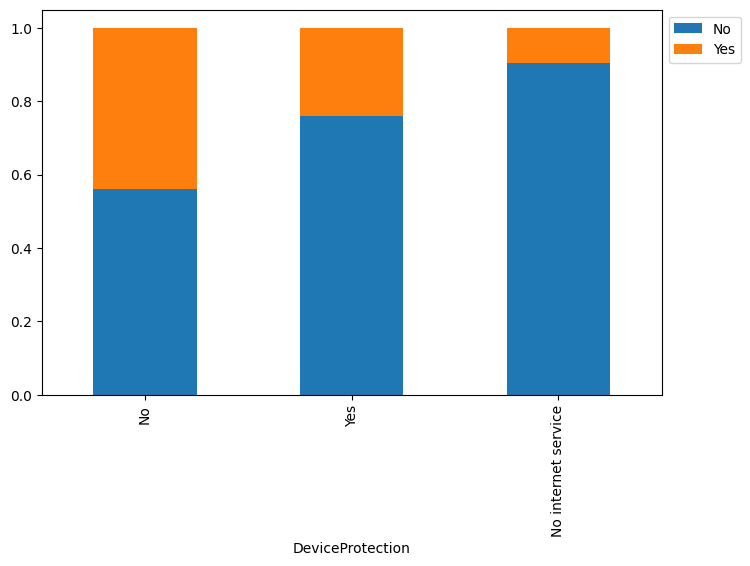

```python
stacked_barplot(df, "DeviceProtection", "Churn_New")
```

- Customers who **have Device protection** are significantly **less likely to churn** compared to those without Device protection service.

**Observations on Customer Churn and Contract**

```
Churn_New         No   Yes    All
Contract
All             8634  3394  12028
Month-to-month  3527  3006   6533
One year        2265   290   2555
Two year        2842    98   2940
------------------------------------------------------------------------------------------------------------------------
```

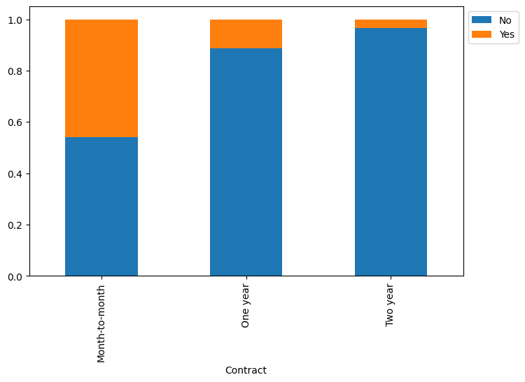

```python
stacked_barplot(df, "Contract", "Churn_New")
```

**Observations on Customer Churn and Paperless Billing**

```
Churn_New           No   Yes    All
PaperlessBilling
All               8634  3394  12028
Yes               3929  2215   6144
No                4705  1179   5884
------------------------------------------------------------------------------------------------------------------------
```

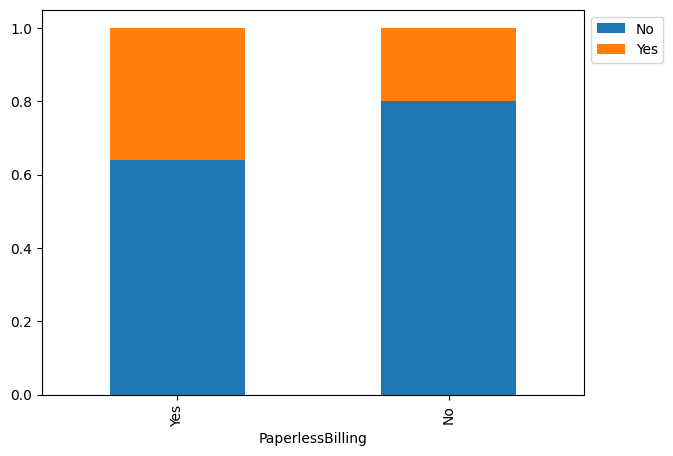

```python
stacked_barplot(df, "PaperlessBilling", "Churn_New")
```

- Customers who use **Paperless billing** show a notably **higher rate of churn**(**~36%**) compared to those(customers) who use traditional Paper billing(~20%).

**Observations on Customer Churn and Payment Method**

```
Churn_New                    No   Yes    All
PaymentMethod_New
All                        8634  3394  12028
Electronic Check           2106  2030   4136
Mailed Check               2002   570   2572
Credit Card (Automatic)    2516   412   2928
Bank Transfer (Automatic)  2010   382   2392
------------------------------------------------------------------------------------------------------------------------
```

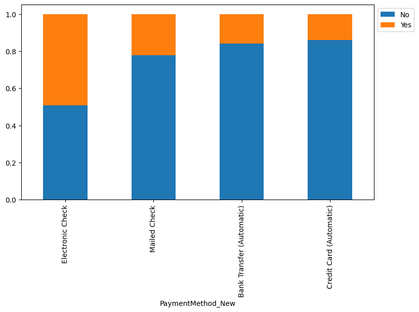

```python
stacked_barplot(df, "PaymentMethod_New", "Churn_New")
```

- A significantly higher proportion of customers using **Electronic Checks** are **churning**(**~49%**) compared to other payment method.

**Observations on Customer Churn and Numerical Variables**

> **Customer Churn vs tenure**

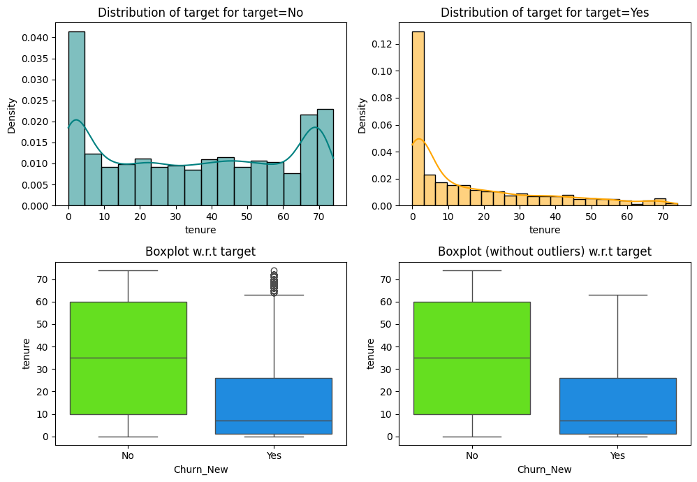

```python
distribution_plot_wrt_target(df, "tenure", "Churn_New")
```

- A significant portion of churn occurs among newer customers with very short tenures(typically within the first few months)
- The boxplot for churned customers typically shows a concentration at lower tenure values. However, there are outliers extending to higher tenure values.

> **Customer Churn vs Total Charges**

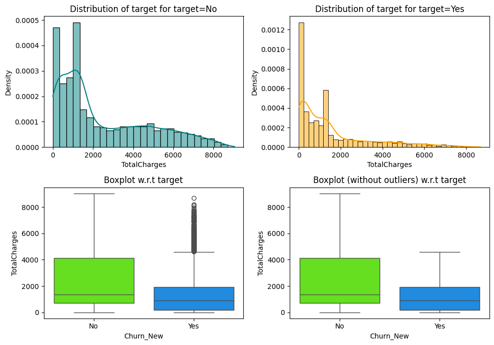

```python
distribution_plot_wrt_target(df, "TotalCharges", "Churn_New")
```

- The distribution for churn customers is heavily skewed towards the lower end of total charges. The majority of the customers have total charges below approximately 2000.
- This shows non-churned customers are valuable subscribers who are less likely to leave.
- There are outliers in boxplots of churned customers(Yes).

> **Customer Churn vs Monthly Charges**

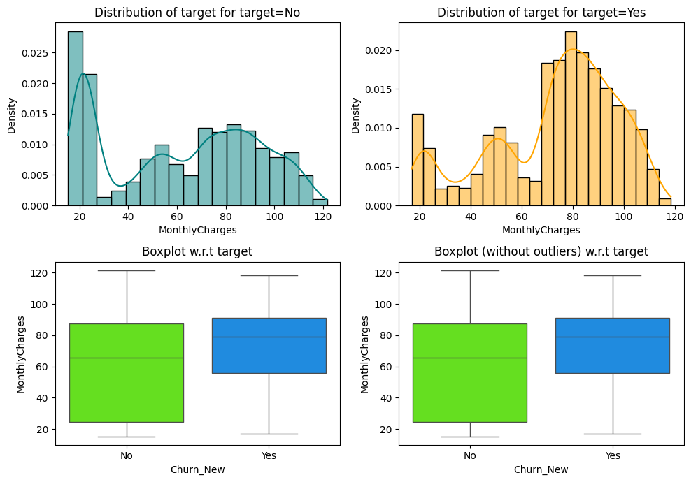

```python
distribution_plot_wrt_target(df,'MonthlyCharges', 'Churn_New')
```

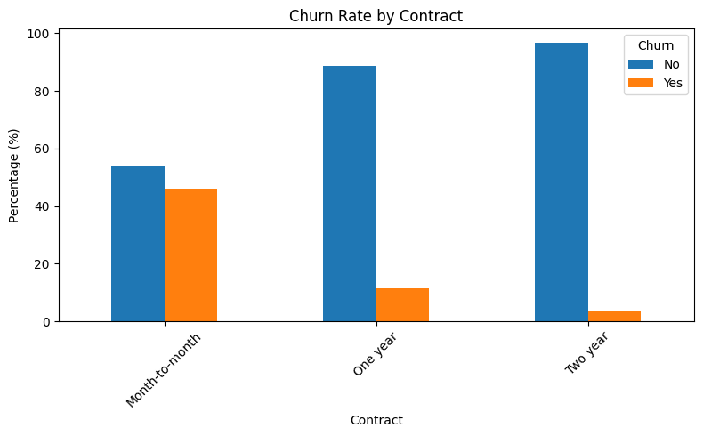

```python
import matplotlib.pyplot as plt
import seaborn as sns

def plot_churn_rate(df, column):
    churn_data = df.groupby(column)['Churn_New'].value_counts(normalize=True).unstack()
    churn_data = churn_data * 100

    churn_data.plot(kind='bar', stacked=False, figsize=(8, 5))
    plt.title(f'Churn Rate by {column}')
    plt.ylabel('Percentage (%)')
    plt.xlabel(column)
    plt.legend(title='Churn')
    plt.xticks(rotation=45)
    plt.tight_layout()
    plt.show()


plot_churn_rate(df, 'Contract')
```

- Longer contract durations effectively increase customer retention but in month-to-month contracts customers are more likely to leave due to dissatisfaction.

# **Multivariate Analysis**

> **Pairplot for Numerical features and Customer Churn**

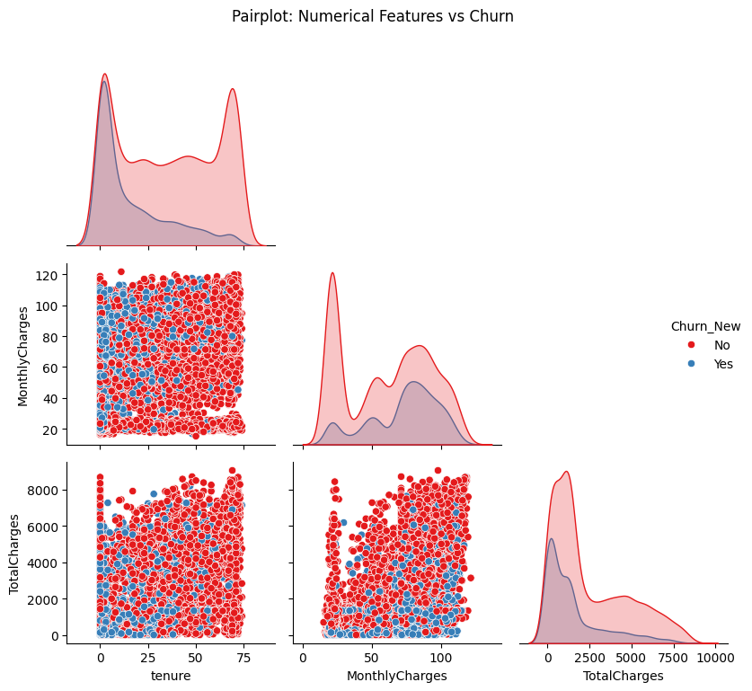

```python
# Pairplot to see relationships between all numerical variables
sns.pairplot(df[num_cols + ['Churn_New']], hue='Churn_New',
             diag_kind='kde', palette='Set1', corner=True)
plt.suptitle('Pairplot: Numerical Features vs Churn', y=1.02)
plt.tight_layout()
plt.show()
```

```
==================================================
                                                              Churn_Rate_%  \
Contract       PaymentMethod_New         TechSupport
Month-to-month Electronic Check          No                         63.000
               Mailed Check              No                         44.260
               Bank Transfer (Automatic) No                         39.830
               Credit Card (Automatic)   No                         38.330
               Electronic Check          Yes                        36.170
                                         No internet service        27.720
               Credit Card (Automatic)   Yes                        25.140
               Bank Transfer (Automatic) No internet service        24.350
               Mailed Check              Yes                        23.890
One year       Electronic Check          No                         22.620
Month-to-month Mailed Check              No internet service        22.420
               Bank Transfer (Automatic) Yes                        21.180
One year       Mailed Check              No                         16.070
Month-to-month Credit Card (Automatic)   No internet service        16.000
One year       Electronic Check          Yes                        14.680

                                                              Customer_Count
Contract       PaymentMethod_New         TechSupport
Month-to-month Electronic Check          No                             2738
               Mailed Check              No                              793
               Bank Transfer (Automatic) No                              580
               Credit Card (Automatic)   No                              634
               Electronic Check          Yes                             376
                                         No internet service             101
               Credit Card (Automatic)   Yes                             183
               Bank Transfer (Automatic) No internet service             115
               Mailed Check              Yes                             180
One year       Electronic Check          No                              367
Month-to-month Mailed Check              No internet service             513
               Bank Transfer (Automatic) Yes                             170
One year       Mailed Check              No                              112
Month-to-month Credit Card (Automatic)   No internet service             150
One year       Electronic Check          Yes                             218


LOWEST CHURN COMBINATIONS:
                                                        Churn_Rate_%  \
```

[output cut: 10 more lines]

```
         Mailed Check              Yes                         0.750

                                                        Customer_Count
Contract PaymentMethod_New         TechSupport
One year Bank Transfer (Automatic) No internet service             142
Two year Mailed Check              No internet service             412
One year Credit Card (Automatic)   No internet service             187
Two year Bank Transfer (Automatic) Yes                             429
         Credit Card (Automatic)   No internet service             499
         Bank Transfer (Automatic) No internet service             348
         Electronic Check          No internet service              40
         Credit Card (Automatic)   No                              170
                                   Yes                             474
         Mailed Check              Yes                             134
==================================================
```

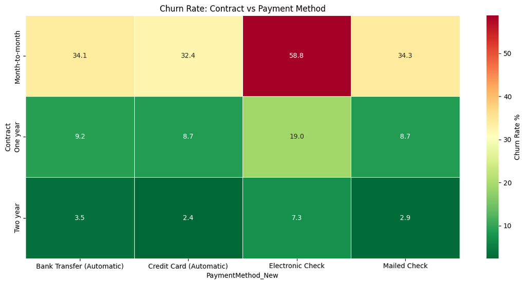

```python
# Analyze all combinations of these 3 features
contract_payment_tech = df.groupby(['Contract', 'PaymentMethod_New', 'TechSupport']).agg({
    'Churn_New': lambda x: (x == 'Yes').sum() / len(x) * 100,
    'gender': 'count'  # Using any column for count
}).rename(columns={'Churn_New': 'Churn_Rate_%', 'gender': 'Customer_Count'})

contract_payment_tech = contract_payment_tech.round(2)
contract_payment_tech = contract_payment_tech.sort_values('Churn_Rate_%', ascending=False)


print("="*50)
print(contract_payment_tech.head(15))  # Top 15 combinations
print("\n")
print("LOWEST CHURN COMBINATIONS:")
print(contract_payment_tech.tail(10))  # Bottom 10 combinations
print("="*50)

# Visualize with heatmap
import seaborn as sns
import matplotlib.pyplot as plt

# Create pivot for better visualization (Contract vs PaymentMethod, averaged across TechSupport)
pivot_data = df.groupby(['Contract', 'PaymentMethod_New'])['Churn_New'].apply(
    lambda x: (x == 'Yes').sum() / len(x) * 100
).unstack()

plt.figure(figsize=(12, 6))
sns.heatmap(pivot_data, annot=True, fmt='.1f', cmap='RdYlGn_r',
            linewidths=0.5, cbar_kws={'label': 'Churn Rate %'})
plt.title('Churn Rate: Contract vs Payment Method')
plt.tight_layout()
plt.show()
```

- The highest churn rate is observed for month-to-month contracts using **Electronic Check payments(58.8%)**.
- The lowest churn rate is observed for Two-year contracts using **Credit Card(Automatic payments)(2.4%)**.

```python
# Test multiple feature combinations to find highest risk
def find_highest_risk_combinations(df, max_combinations=20):
    """Find the highest risk customer profiles"""

    # Define features to test
    feature_combinations = [
        ['Contract', 'InternetService'],
        ['Contract', 'InternetService', 'TechSupport'],
        ['Contract', 'InternetService', 'TechSupport', 'OnlineSecurity'],
        ['Contract', 'InternetService', 'PaymentMethod_New'],
        ['Contract', 'InternetService', 'TechSupport', 'PaymentMethod_New'],
        ['Contract', 'PaymentMethod_New', 'TechSupport', 'OnlineSecurity'],
        ['SeniorCitizen', 'Contract', 'InternetService', 'TechSupport'],
        ['Contract', 'InternetService', 'TechSupport', 'OnlineSecurity', 'OnlineBackup'],
    ]

    all_results = []

    for features in feature_combinations:
        grouped = df.groupby(features).agg({
            'Churn_New': lambda x: (x == 'Yes').sum() / len(x) * 100,
            'gender': 'count'
        }).rename(columns={'gender': 'Customer_Count', 'Churn_New': 'Churn_Rate_%'})

        # Only include combinations with at least 10 customers
        grouped = grouped[grouped['Customer_Count'] >= 10]

        # Get top result
        if len(grouped) > 0:
            top_combo = grouped.sort_values('Churn_Rate_%', ascending=False).head(1)

            # Get the feature values
            combo_values = ' + '.join([f"{feat}={val}" for feat, val in zip(features, top_combo.index[0])])

            all_results.append({
                'Feature_Combination': ' + '.join(features),
                'Profile': combo_values,
                'Churn_Rate_%': top_combo['Churn_Rate_%'].values[0],
                'Customer_Count': int(top_combo['Customer_Count'].values[0])
            })

    results_df = pd.DataFrame(all_results).sort_values('Churn_Rate_%', ascending=False)
    return results_df


print("="*70)
highest_risk = find_highest_risk_combinations(df)
print(highest_risk.head(20))
print("="*70)

# Get THE absolute highest risk profile with sufficient customers
print("\n HIGHEST RISK PROFILE:")
print("-"*70)
top_risk = highest_risk.iloc[0]
print(f"Profile: {top_risk['Profile']}")
print(f"Churn Rate: {top_risk['Churn_Rate_%']:.2f}%")
print(f"Customer Count: {top_risk['Customer_Count']}")
print("="*70)
```

```
======================================================================
                                 Feature_Combination  \
7  Contract + InternetService + TechSupport + Onl...
4  Contract + InternetService + TechSupport + Pay...
5  Contract + PaymentMethod_New + TechSupport + O...
2  Contract + InternetService + TechSupport + Onl...
3     Contract + InternetService + PaymentMethod_New
6  SeniorCitizen + Contract + InternetService + T...
1           Contract + InternetService + TechSupport
0                         Contract + InternetService

                                             Profile  Churn_Rate_%  \
7  Contract=Month-to-month + InternetService=Fibe...        68.103
4  Contract=Month-to-month + InternetService=Fibe...        67.242
5  Contract=Month-to-month + PaymentMethod_New=El...        65.634
2  Contract=Month-to-month + InternetService=Fibe...        65.180
3  Contract=Month-to-month + InternetService=Fibe...        64.633
6  SeniorCitizen=Yes + Contract=Month-to-month + ...        63.158
1  Contract=Month-to-month + InternetService=Fibe...        62.375
0  Contract=Month-to-month + InternetService=Fibe...        59.190

   Customer_Count
7            1903
4            2027
5            2421
2            2556
3            2262
6             684
1            2905
0            3335
======================================================================

 HIGHEST RISK PROFILE:
----------------------------------------------------------------------
Profile: Contract=Month-to-month + InternetService=Fiber optic + TechSupport=No + OnlineSecurity=No + OnlineBackup=No
Churn Rate: 68.10%
Customer Count: 1903
======================================================================
```

- The analysis identifies that **Contract : month-to-month, InternetService : Fibre optic, TechSupport : No, OnlineSecurity : No, OnlineBackup : No** are the **highest risk customer segments** with a significant churn rate of **68.10%**.

# Outlier Detection and Treatment

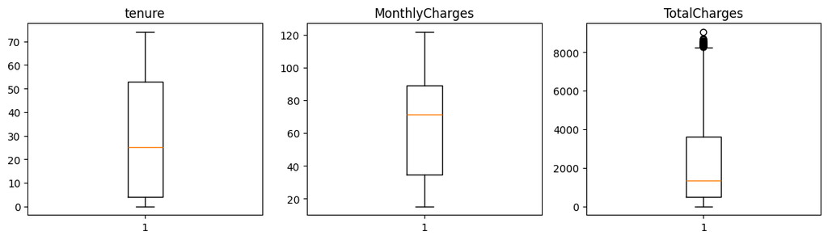

```python
# outlier detection using boxplot
numeric_columns = df.select_dtypes(include=np.number).columns.tolist()


plt.figure(figsize=(15, 12))

for i, variable in enumerate(numeric_columns):
    plt.subplot(4, 4, i + 1)
    plt.boxplot(df[variable], whis=1.5)
    plt.tight_layout()
    plt.title(variable)

plt.show()
```

- Although outliers exist so we will keep them as they may have a valuable input.

# Feature Engineering

```python
# Create tenure groups based on insights
df['tenure_group'] = pd.cut(df['tenure'],
                             bins=[0, 12, 36, 60, df['tenure'].max()],
                             labels=['New (0-12)', 'Medium (13-36)', 'Long (37-60)', 'Very Long (60+)'],
                             include_lowest=True)

# Verify the distribution
print(df['tenure_group'].value_counts())
```

```
tenure_group
New (0-12)         4444
Medium (13-36)     2796
Long (37-60)       2562
Very Long (60+)    2226
Name: count, dtype: int64
```

- We have created a tenure_group column for better analysis.

# Data preparation for Modeling

> **Creating Training and Test set**

```python
# target variable
y=df['Churn_New'].map({'Yes':1,'No':0})
```

```python
# Dropping Churn_New and tenure column
X=df.drop(['Churn_New','tenure'], axis=1)
```

```python
# Splitting data into training and validation set:

X_train, X_temp, y_train, y_temp = train_test_split(X, y, test_size=0.30, stratify=y, random_state=1)

X_test, X_val, y_test, y_val = train_test_split(X_temp, y_temp, test_size=0.50, stratify=y_temp, random_state=1 )

print(X_train.shape, X_val.shape, X_test.shape)
```

```
(8419, 19) (1805, 19) (1804, 19)
```

- There are 8419 rows in training data, 1805 rows in validation data and 1804 rows in test data. All the datasets have 19 attributes.

```python
# Checking that no column has missing values in train, validation and test sets
print(X_train.isna().sum())
print("-" * 30)
print(X_val.isna().sum())
print("-" * 30)
print(X_test.isna().sum())
```

```
gender               0
SeniorCitizen        0
Partner              0
Dependents           0
PhoneService         0
MultipleLines        0
InternetService      0
OnlineSecurity       0
OnlineBackup         0
DeviceProtection     0
TechSupport          0
StreamingTV          0
StreamingMovies      0
Contract             0
PaperlessBilling     0
MonthlyCharges       0
TotalCharges         0
PaymentMethod_New    0
tenure_group         0
dtype: int64
------------------------------
gender               0
SeniorCitizen        0
Partner              0
Dependents           0
PhoneService         0
MultipleLines        0
InternetService      0
OnlineSecurity       0
OnlineBackup         0
DeviceProtection     0
TechSupport          0
StreamingTV          0
StreamingMovies      0
Contract             0
PaperlessBilling     0
MonthlyCharges       0
TotalCharges         0
PaymentMethod_New    0
tenure_group         0
dtype: int64
------------------------------
gender               0
SeniorCitizen        0
Partner              0
Dependents           0
PhoneService         0
MultipleLines        0
InternetService      0
OnlineSecurity       0
OnlineBackup         0
DeviceProtection     0
TechSupport          0
StreamingTV          0
StreamingMovies      0
Contract             0
PaperlessBilling     0
MonthlyCharges       0
TotalCharges         0
PaymentMethod_New    0
tenure_group         0
dtype: int64
```

# Encoding categorical variables

```python
X_train = pd.get_dummies(X_train, drop_first=True)
X_val = pd.get_dummies(X_val, drop_first=True)  ## Complete the code to impute missing values in X_val
X_test = pd.get_dummies(X_test, drop_first=True)  ## Complete the code to impute missing values in X_val
print(X_train.shape, X_val.shape, X_test.shape)
print(X_train.shape, X_test.shape)
```

```
(8419, 32) (1805, 32) (1804, 32)
(8419, 32) (1804, 32)
```

# Model evaluation criterion

**A Customer Churn prediction model can make incorrect predictions in the following ways:**

- **False Positive :** The model predicts non-churner as a churner. This may lead to unnecessary retention efforts or offers being extended to customers who would not have churned.
- **False Negative :** The model predicts a churner as a non-churner. In this case a customer who is likely to leave is not identified in right time that could result a potential revenue loss.

# Which Loss is greater?

- **False negatives** are more costly for the company because they represent customers who actually churn but were not flagged by the model.

# How to reduce this loss i.e need to reduce False Negatives?

- Company wants **recall** to be maximized i.e. we need to reduce the number of false negatives.

# First, let's create functions to calculate different metrics and confusion matrix so that we don't have to use the same code repeatedly for each model.

- The model_performance_classification_statsmodels function will be used to check the model performance of models.
- The confusion_matrix_statsmodels function will be used to plot confusion matrix.

```python
# defining a function to compute different metrics to check performance of a classification model built using statsmodels
def model_performance_classification_statsmodels(
    model, predictors, target, threshold=0.5
):
    """
    Function to compute different metrics to check classification model performance

    model: classifier
    predictors: independent variables
    target: dependent variable
    threshold: threshold for classifying the observation as class 1
    """

    # checking which probabilities are greater than threshold
    pred_temp = model.predict(predictors) > threshold
    # rounding off the above values to get classes
    pred = np.round(pred_temp)

    acc = accuracy_score(target, pred)  # to compute Accuracy
    recall = recall_score(target, pred)  # to compute Recall
    precision = precision_score(target, pred)  # to compute Precision
    f1 = f1_score(target, pred)  # to compute F1-score

    # creating a dataframe of metrics
    df_perf = pd.DataFrame(
        {"Accuracy": acc, "Recall": recall, "Precision": precision, "F1": f1,},
        index=[0],
    )

    return df_perf
```

```python
# defining a function to plot the confusion_matrix of a classification model


def confusion_matrix_statsmodels(model, predictors, target, threshold=0.5):
    """
    To plot the confusion_matrix with percentages

    model: classifier
    predictors: independent variables
    target: dependent variable
    threshold: threshold for classifying the observation as class 1
    """
    y_pred = model.predict(predictors) > threshold
    cm = confusion_matrix(target, y_pred)
    labels = np.asarray(
        [
            ["{0:0.0f}".format(item) + "\n{0:.2%}".format(item / cm.flatten().sum())]
            for item in cm.flatten()
        ]
    ).reshape(2, 2)

    plt.figure(figsize=(6, 4))
    sns.heatmap(cm, annot=labels, fmt="")
    plt.ylabel("True label")
    plt.xlabel("Predicted label")
```

# **Logistic Regression**

```python
X_train_sm = sm.add_constant(X_train.astype(float))

logit = sm.Logit(y_train, X_train_sm)
lg = logit.fit(
    disp=False
)  # setting disp=False will remove the information on number of iterations

print(lg.summary())
```

```
                           Logit Regression Results
==============================================================================
Dep. Variable:              Churn_New   No. Observations:                 8419
Model:                          Logit   Df Residuals:                     8386
Method:                           MLE   Df Model:                           32
Date:                Sun, 01 Feb 2026   Pseudo R-squ.:                  0.2922
Time:                        09:34:04   Log-Likelihood:                -3546.0
converged:                       True   LL-Null:                       -5009.6
Covariance Type:            nonrobust   LLR p-value:                     0.000
=============================================================================================================
                                                coef    std err          z      P>|z|      [0.025      0.975]
-------------------------------------------------------------------------------------------------------------
const                                        -0.5628      0.241     -2.339      0.019      -1.034      -0.091
MonthlyCharges                                0.0068      0.003      2.594      0.009       0.002       0.012
TotalCharges                                 -0.0001   2.33e-05     -5.835      0.000      -0.000   -9.03e-05
gender_Male                                   0.0710      0.060      1.191      0.234      -0.046       0.188
SeniorCitizen_Yes                             0.1997      0.088      2.269      0.023       0.027       0.372
Partner_Yes                                  -0.0947      0.070     -1.358      0.175      -0.231       0.042
Dependents_Yes                               -0.2060      0.081     -2.553      0.011      -0.364      -0.048
PhoneService_Yes                             -0.0921      0.184     -0.501      0.617      -0.453       0.269
MultipleLines_No phone service                0.0046      0.187      0.025      0.980      -0.362       0.371
MultipleLines_Yes                             0.2881      0.072      3.990      0.000       0.147       0.430
InternetService_Fiber optic                   0.6802      0.094      7.201      0.000       0.495       0.865
InternetService_No                            0.7650      0.585      1.308      0.191      -0.381       1.911
OnlineSecurity_No internet service            0.3288      0.608      0.541      0.589      -0.863       1.521
OnlineSecurity_Yes                           -0.4714      0.082     -5.751      0.000      -0.632      -0.311
OnlineBackup_No internet service             -0.5468      0.563     -0.972      0.331      -1.649       0.556
OnlineBackup_Yes                             -0.3262      0.073     -4.440      0.000      -0.470      -0.182
DeviceProtection_No internet service          0.3982      0.555      0.717      0.473      -0.690       1.487
DeviceProtection_Yes                         -0.0917      0.069     -1.337      0.181      -0.226       0.043
TechSupport_No internet service               0.1183      0.583      0.203      0.839      -1.025       1.261
TechSupport_Yes                              -0.5367      0.086     -6.252      0.000      -0.705      -0.368
StreamingTV_No internet service              -0.7608      0.675     -1.127      0.260      -2.083       0.562
StreamingTV_Yes                               0.0796      0.078      1.018      0.309      -0.074       0.233
StreamingMovies_No internet service          -1.2389      0.681     -1.818      0.069      -2.575       0.097
StreamingMovies_Yes                          -0.0153      0.077     -0.198      0.843      -0.167       0.136
Contract_One year                            -0.8159      0.093     -8.747      0.000      -0.999      -0.633
Contract_Two year                            -1.5841      0.148    -10.734      0.000      -1.873      -1.295
PaperlessBilling_Yes                          0.3101      0.064      4.820      0.000       0.184       0.436
PaymentMethod_New_Credit Card (Automatic)    -0.0649      0.107     -0.609      0.543      -0.274       0.144
PaymentMethod_New_Electronic Check            0.4535      0.090      5.017      0.000       0.276       0.631
PaymentMethod_New_Mailed Check                0.1168      0.107      1.097      0.273      -0.092       0.326
tenure_group_Medium (13-36)                  -0.7635      0.076    -10.018      0.000      -0.913      -0.614
tenure_group_Long (37-60)                    -0.8934      0.100     -8.943      0.000      -1.089      -0.698
tenure_group_Very Long (60+)                 -1.0975      0.153     -7.173      0.000      -1.397      -0.798
=============================================================================================================
```

```python
X_train_sm
```

|  | const | MonthlyCharges | TotalCharges | gender_Male | SeniorCitizen_Yes | Partner_Yes | Dependents_Yes | PhoneService_Yes | MultipleLines_No phone service | MultipleLines_Yes | InternetService_Fiber optic | InternetService_No | OnlineSecurity_No internet service | OnlineSecurity_Yes | OnlineBackup_No internet service | OnlineBackup_Yes | DeviceProtection_No internet service | DeviceProtection_Yes | TechSupport_No internet service | TechSupport_Yes | StreamingTV_No internet service | StreamingTV_Yes | StreamingMovies_No internet service | StreamingMovies_Yes | Contract_One year | Contract_Two year | PaperlessBilling_Yes | PaymentMethod_New_Credit Card (Automatic) | PaymentMethod_New_Electronic Check | … |
| --- | --- | --- | --- | --- | --- | --- | --- | --- | --- | --- | --- | --- | --- | --- | --- | --- | --- | --- | --- | --- | --- | --- | --- | --- | --- | --- | --- | --- | --- | --- |
| 5979 | 1.000 | 19.650 | 978.000 | 1.000 | 0.000 | 0.000 | 0.000 | 1.000 | 0.000 | 0.000 | 0.000 | 1.000 | 1.000 | 0.000 | 1.000 | 0.000 | 1.000 | 0.000 | 1.000 | 0.000 | 1.000 | 0.000 | 1.000 | 0.000 | 0.000 | 1.000 | 0.000 | 0.000 | 0.000 | … |
| 3236 | 1.000 | 55.300 | 875.350 | 1.000 | 0.000 | 0.000 | 0.000 | 1.000 | 0.000 | 1.000 | 0.000 | 0.000 | 0.000 | 0.000 | 0.000 | 1.000 | 0.000 | 0.000 | 0.000 | 0.000 | 0.000 | 0.000 | 0.000 | 0.000 | 0.000 | 0.000 | 0.000 | 0.000 | 1.000 | … |
| 10759 | 1.000 | 89.160 | 761.270 | 0.000 | 0.000 | 1.000 | 0.000 | 1.000 | 0.000 | 1.000 | 0.000 | 0.000 | 0.000 | 0.000 | 0.000 | 0.000 | 0.000 | 1.000 | 0.000 | 0.000 | 0.000 | 1.000 | 0.000 | 0.000 | 1.000 | 0.000 | 1.000 | 0.000 | 0.000 | … |
| 2817 | 1.000 | 20.650 | 875.550 | 0.000 | 0.000 | 1.000 | 0.000 | 1.000 | 0.000 | 0.000 | 0.000 | 1.000 | 1.000 | 0.000 | 1.000 | 0.000 | 1.000 | 0.000 | 1.000 | 0.000 | 1.000 | 0.000 | 1.000 | 0.000 | 0.000 | 1.000 | 0.000 | 1.000 | 0.000 | … |
| 4537 | 1.000 | 49.800 | 836.350 | 1.000 | 0.000 | 1.000 | 0.000 | 0.000 | 1.000 | 0.000 | 0.000 | 0.000 | 0.000 | 0.000 | 0.000 | 1.000 | 0.000 | 0.000 | 0.000 | 0.000 | 0.000 | 1.000 | 0.000 | 1.000 | 0.000 | 0.000 | 1.000 | 0.000 | 0.000 | … |
| ... | ... | ... | ... | ... | ... | ... | ... | ... | ... | ... | ... | ... | ... | ... | ... | ... | ... | ... | ... | ... | ... | ... | ... | ... | ... | ... | ... | ... | ... | … |
| 576 | 1.000 | 98.050 | 3082.100 | 1.000 | 0.000 | 1.000 | 1.000 | 1.000 | 0.000 | 1.000 | 1.000 | 0.000 | 0.000 | 1.000 | 0.000 | 0.000 | 0.000 | 1.000 | 0.000 | 0.000 | 0.000 | 1.000 | 0.000 | 0.000 | 1.000 | 0.000 | 0.000 | 0.000 | 0.000 | … |
| 3728 | 1.000 | 88.800 | 5903.150 | 1.000 | 0.000 | 0.000 | 0.000 | 1.000 | 0.000 | 1.000 | 0.000 | 0.000 | 0.000 | 1.000 | 0.000 | 1.000 | 0.000 | 1.000 | 0.000 | 1.000 | 0.000 | 1.000 | 0.000 | 1.000 | 1.000 | 0.000 | 1.000 | 0.000 | 0.000 | … |
| 9396 | 1.000 | 22.950 | 1732.230 | 1.000 | 0.000 | 0.000 | 0.000 | 1.000 | 0.000 | 0.000 | 0.000 | 1.000 | 1.000 | 0.000 | 1.000 | 0.000 | 1.000 | 0.000 | 1.000 | 0.000 | 1.000 | 0.000 | 1.000 | 0.000 | 0.000 | 1.000 | 0.000 | 1.000 | 0.000 | … |
| 1916 | 1.000 | 84.800 | 3862.550 | 0.000 | 0.000 | 0.000 | 0.000 | 1.000 | 0.000 | 1.000 | 1.000 | 0.000 | 0.000 | 0.000 | 0.000 | 1.000 | 0.000 | 1.000 | 0.000 | 0.000 | 0.000 | 0.000 | 0.000 | 0.000 | 0.000 | 0.000 | 1.000 | 0.000 | 0.000 | … |
| 10482 | 1.000 | 53.030 | 1234.750 | 1.000 | 0.000 | 1.000 | 0.000 | 1.000 | 0.000 | 1.000 | 0.000 | 0.000 | 0.000 | 1.000 | 0.000 | 0.000 | 0.000 | 1.000 | 0.000 | 0.000 | 0.000 | 1.000 | 0.000 | 1.000 | 0.000 | 0.000 | 0.000 | 1.000 | 0.000 | … |

8419 rows × 33 columns

# Additional Information on VIF

- **Variance Inflation factor:** Variance inflation factors measure the inflation in the variances of the regression coefficients estimates due to collinearity that exist among the predictors. It is a measure of how much the variance of the estimated regression coefficient βk is "inflated" by the existence of correlation among the predictor variables in the model.
- General Rule of thumb: If VIF is 1 then there is no correlation among the kth predictor and the remaining predictor variables, and hence the variance of β̂k is not inflated at all. Whereas if VIF exceeds 5, we say there is moderate VIF and if it is 10 or exceeding 10, it shows signs of high multi-collinearity. But the purpose of the analysis should dictate which threshold to use.

```python
vif_series = pd.Series(
    [variance_inflation_factor(X_train_sm.values, i) for i in range(X_train_sm.shape[1])],
    index=X_train_sm.columns,
    dtype=float,
)
print("Series before feature selection: \n\n{}\n".format(vif_series))
```

```
Series before feature selection:

const                                       72.831
MonthlyCharges                               7.597
TotalCharges                                 2.705
gender_Male                                  1.009
SeniorCitizen_Yes                            1.091
Partner_Yes                                  1.316
Dependents_Yes                               1.240
PhoneService_Yes                             4.175
MultipleLines_No phone service               4.240
MultipleLines_Yes                            1.442
InternetService_Fiber optic                  2.674
InternetService_No                          72.439
OnlineSecurity_No internet service          60.634
OnlineSecurity_Yes                           1.366
OnlineBackup_No internet service            58.768
OnlineBackup_Yes                             1.300
DeviceProtection_No internet service        61.762
DeviceProtection_Yes                         1.532
TechSupport_No internet service             59.516
TechSupport_Yes                              1.507
StreamingTV_No internet service             70.006
StreamingTV_Yes                              1.783
StreamingMovies_No internet service         72.369
StreamingMovies_Yes                          1.743
Contract_One year                            1.556
Contract_Two year                            2.248
PaperlessBilling_Yes                         1.197
PaymentMethod_New_Credit Card (Automatic)    1.681
PaymentMethod_New_Electronic Check           2.145
PaymentMethod_New_Mailed Check               1.875
tenure_group_Medium (13-36)                  1.361
tenure_group_Long (37-60)                    1.742
tenure_group_Very Long (60+)                 2.476
dtype: float64
```

```python
# Create X_train with constant added once to be used throughout the feature selection
X_train_features_with_const = sm.add_constant(X_train.astype(float), prepend=True)

# initial list of columns, including 'const'
cols_for_selection = X_train_features_with_const.columns.tolist()

# setting an initial max p-value
max_p_value = 1

while len(cols_for_selection) > 0:
    # defining the train set for the current iteration
    X_train_aux = X_train_features_with_const[cols_for_selection]

    # fitting the model
    model = sm.Logit(y_train, X_train_aux).fit(disp=False)

    # getting the p-values and the maximum p-value
    p_values = model.pvalues
    max_p_value = p_values.max()

    # name of the variable with maximum p-value
    feature_with_p_max = p_values.idxmax()

    # If the max p-value is greater than 0.05, and it's not the constant, remove the feature
    if max_p_value > 0.05:
        if feature_with_p_max == 'const':
            # If 'const' is the most insignificant, we stop removing features
            # as 'const' is almost always retained.
            break
        else:
            cols_for_selection.remove(feature_with_p_max)
    else:
        break

selected_features = cols_for_selection
print(selected_features)
```

```
['const', 'MonthlyCharges', 'TotalCharges', 'SeniorCitizen_Yes', 'Dependents_Yes', 'MultipleLines_Yes', 'InternetService_Fiber optic', 'OnlineSecurity_Yes', 'OnlineBackup_Yes', 'TechSupport_Yes', 'StreamingMovies_No internet service', 'Contract_One year', 'Contract_Two year', 'PaperlessBilling_Yes',…
```

- The above columns are the significant column.

```python
# Add constant to X_train, X_val, X_test before selecting features
X_train_with_const = sm.add_constant(X_train.astype(float), prepend=True)
X_val_with_const = sm.add_constant(X_val.astype(float), prepend=True)
X_test_with_const = sm.add_constant(X_test.astype(float), prepend=True)

# Select only the significant features from these dataframes
X_train1 = X_train_with_const[selected_features]
X_val1 = X_val_with_const[selected_features]
X_test1 = X_test_with_const[selected_features]
```

```python
logit2 = sm.Logit(y_train, X_train1) # X_train1 now includes the constant
lg2 = logit2.fit(disp=False)
print(lg2.summary())
```

```
                           Logit Regression Results
==============================================================================
Dep. Variable:              Churn_New   No. Observations:                 8419
Model:                          Logit   Df Residuals:                     8401
Method:                           MLE   Df Model:                           17
Date:                Sun, 01 Feb 2026   Pseudo R-squ.:                  0.2907
Time:                        09:34:06   Log-Likelihood:                -3553.2
converged:                       True   LL-Null:                       -5009.6
Covariance Type:            nonrobust   LLR p-value:                     0.000
=======================================================================================================
                                          coef    std err          z      P>|z|      [0.025      0.975]
-------------------------------------------------------------------------------------------------------
const                                  -0.5365      0.133     -4.040      0.000      -0.797      -0.276
MonthlyCharges                          0.0063      0.002      2.808      0.005       0.002       0.011
TotalCharges                           -0.0001   2.26e-05     -6.197      0.000      -0.000   -9.59e-05
SeniorCitizen_Yes                       0.1911      0.087      2.190      0.029       0.020       0.362
Dependents_Yes                         -0.2454      0.076     -3.241      0.001      -0.394      -0.097
MultipleLines_Yes                       0.2738      0.071      3.870      0.000       0.135       0.412
InternetService_Fiber optic             0.6583      0.091      7.203      0.000       0.479       0.837
OnlineSecurity_Yes                     -0.4793      0.082     -5.873      0.000      -0.639      -0.319
OnlineBackup_Yes                       -0.3242      0.073     -4.433      0.000      -0.468      -0.181
TechSupport_Yes                        -0.5403      0.085     -6.335      0.000      -0.708      -0.373
StreamingMovies_No internet service    -0.9418      0.127     -7.426      0.000      -1.190      -0.693
Contract_One year                      -0.8269      0.092     -8.980      0.000      -1.007      -0.646
Contract_Two year                      -1.6062      0.146    -10.982      0.000      -1.893      -1.320
PaperlessBilling_Yes                    0.3056      0.064      4.792      0.000       0.181       0.431
PaymentMethod_New_Electronic Check      0.4369      0.065      6.748      0.000       0.310       0.564
tenure_group_Medium (13-36)            -0.7806      0.075    -10.350      0.000      -0.928      -0.633
tenure_group_Long (37-60)              -0.9157      0.099     -9.285      0.000      -1.109      -0.722
tenure_group_Very Long (60+)           -1.1322      0.152     -7.471      0.000      -1.429      -0.835
=======================================================================================================
```

**Now no feature has p-value greater than 0.05, so we'll consider the features in X_train1 as the final ones and lg2 as final model.**

# Observations

- **MonthlyCharges :** The coefficient is positive(0.0063). This suggests that higher monthly charges increase the odds of a customer churning.
- **Totalcharges :** The coefficient is negative(-0.0001). This indicates that as TotalCharges increases, the odds of churning decreases. It might suggest that customers with a high total historical spend are less likely to leave.
- **InternetService_Fibre optic :** The coefficient is positive(0.6583). This indicates customers, those who have using Fibre optic service are more likely to churn. This might point to dissatisfaction with fibre service quality, speed or cost.
- **Contract One year & Two year :** Coefficient for both are negative(-0.8269 & -1.6062). Which indicates customers on longer term contracts are much less likely to churn than those on month-to-month basis.
- **PaymentMethod_Electronic check :** The coefficient is positive(0.4369). That indicates customers using Electronic checks are more likely to churn compared to other payment method.

# Converting coefficients to odds

- The coefficients of the logistic regression model are in terms of log(odd), to find the odds we have to take the exponential of the coefficients.
- Therefore, **odds = exp(b)**
- The percentage change in odds is given as **odds = (exp(b) - 1) * 100**

```python
# converting coefficients to odds
odds = np.exp(lg2.params)

# finding the percentage change
perc_change_odds = (np.exp(lg2.params) - 1) * 100

# removing limit from number of columns to display
pd.set_option("display.max_columns", None)

# adding the odds to a dataframe
pd.DataFrame({"Odds": odds, "Change_odd%": perc_change_odds}, index=lg2.params.index).T
```

|  | const | MonthlyCharges | TotalCharges | SeniorCitizen_Yes | Dependents_Yes | MultipleLines_Yes | InternetService_Fiber optic | OnlineSecurity_Yes | OnlineBackup_Yes | TechSupport_Yes | StreamingMovies_No internet service | Contract_One year | Contract_Two year | PaperlessBilling_Yes | PaymentMethod_New_Electronic Check | tenure_group_Medium (13-36) | tenure_group_Long (37-60) | tenure_group_Very Long (60+) |
| --- | --- | --- | --- | --- | --- | --- | --- | --- | --- | --- | --- | --- | --- | --- | --- | --- | --- | --- |
| Odds | 0.585 | 1.006 | 1.000 | 1.211 | 0.782 | 1.315 | 1.931 | 0.619 | 0.723 | 0.583 | 0.390 | 0.437 | 0.201 | 1.357 | 1.548 | 0.458 | 0.400 | 0.322 |
| Change_odd% | -41.523 | 0.630 | -0.014 | 21.054 | -21.762 | 31.490 | 93.149 | -38.081 | -27.688 | -41.745 | -61.009 | -56.258 | -79.936 | 35.740 | 54.789 | -54.188 | -59.976 | -67.769 |

# Coefficient interpretations

- **MonthlyCharges :** Holding all other features constant a unit change in **MonthlyCharges** will increase the odds of a customer being churned by 1.00 times or a 0.63% increase in odds.
- **TotalCharges :** Holding all other features constant a unit change in **TotalCharges** will decrease the odds of a customer being churned by 1.00 times or a 0.01% decrease in odds.
- **SeniorCitizen_Yes**: Holding all other features constant a unit change in **SeniorCitizen_Yes** will increase the odds of a customer being churned by 1.21 times or a 21% increase in odds.
- **Dependents_Yes :** Holding all other features constant a unit change in **Dependents_Yes** will decrease the odds of a customer being churned by 0.78 times or a 21.76% decrease in odds.

  Interpretation for other attributes can be done similarly.

# Checking model performance on the training set

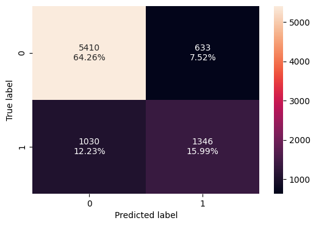

```python
# creating confusion matrix
confusion_matrix_statsmodels(lg2, X_train1, y_train)
```

```python
# Checking model performance for this model
log_reg_model_train_perf=model_performance_classification_statsmodels(lg2,X_train1,y_train)
print('Training Performance')
log_reg_model_train_perf
```

```
Training Performance
```

|  | Accuracy | Recall | Precision | F1 |
| --- | --- | --- | --- | --- |
| 0 | 0.802 | 0.566 | 0.680 | 0.618 |

# ROC-AUC

- ROC-AUC on training set

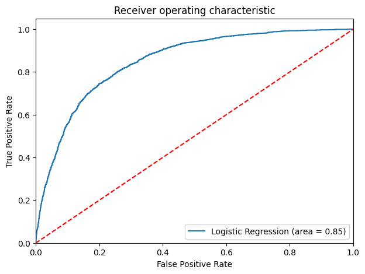

```python
logit_roc_auc_train = roc_auc_score(y_train, lg2.predict(X_train1))
fpr, tpr, thresholds = roc_curve(y_train, lg2.predict(X_train1))
plt.figure(figsize=(7, 5))
plt.plot(fpr, tpr, label="Logistic Regression (area = %0.2f)" % logit_roc_auc_train)
plt.plot([0, 1], [0, 1], "r--")
plt.xlim([0.0, 1.0])
plt.ylim([0.0, 1.05])
plt.xlabel("False Positive Rate")
plt.ylabel("True Positive Rate")
plt.title("Receiver operating characteristic")
plt.legend(loc="lower right")
plt.show()
```

# Optimal threshold using AUC-ROC curve

```python
# Optimal threshold as per AUC-ROC curve
# The optimal cut off would be where tpr is high and fpr is low
fpr, tpr, thresholds = roc_curve(y_train, lg2.predict(X_train1))

optimal_idx = np.argmax(tpr - fpr)
optimal_threshold_auc_roc = thresholds[optimal_idx]
print(optimal_threshold_auc_roc)
```

```
0.34975540084540874
```

# Checking model performance on training set

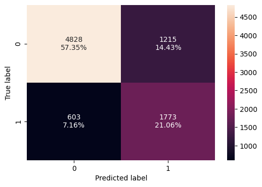

```python
# creating confusion matrix
confusion_matrix_statsmodels(
    lg2, X_train1, y_train, threshold=optimal_threshold_auc_roc
)
```

```python
#Checking model performance for this model
log_reg_model_train_perf_threshold_auc_roc=model_performance_classification_statsmodels(lg2,X_train1,y_train,threshold=optimal_threshold_auc_roc)
print('Training Performance')
log_reg_model_train_perf_threshold_auc_roc
```

```
Training Performance
```

|  | Accuracy | Recall | Precision | F1 |
| --- | --- | --- | --- | --- |
| 0 | 0.784 | 0.746 | 0.593 | 0.661 |

- Model performance has improved.
- Model is giving a recall of 0.74 as compared to initial model which was giving a recall of 0.56.
- Accuracy and precision has slightly decreases from the initial model.

# Let's use Precision-Recall curve and see if we can find a better threshold

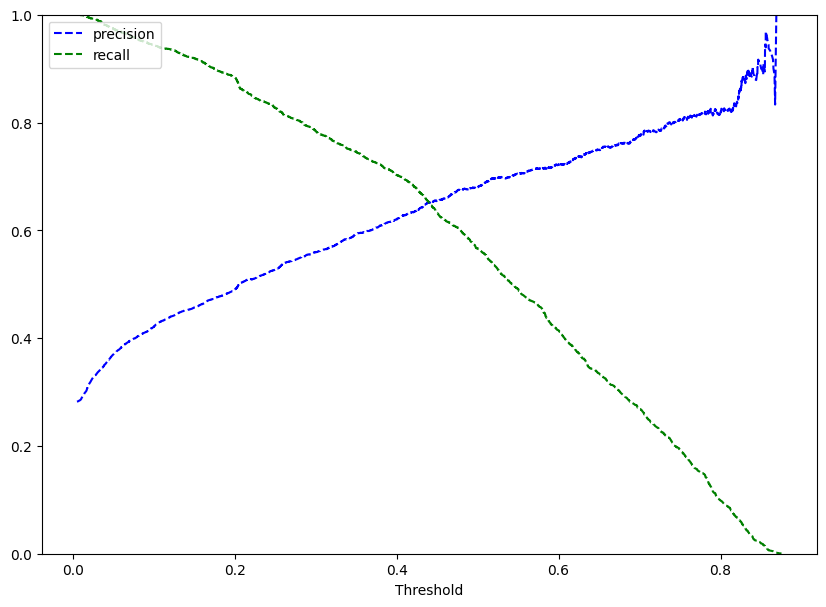

```python
y_scores = lg2.predict(X_train1)
prec, rec, tre = precision_recall_curve(y_train, y_scores,)


def plot_prec_recall_vs_tresh(precisions, recalls, thresholds):
    plt.plot(thresholds, precisions[:-1], "b--", label="precision")
    plt.plot(thresholds, recalls[:-1], "g--", label="recall")
    plt.xlabel("Threshold")
    plt.legend(loc="upper left")
    plt.ylim([0, 1])


plt.figure(figsize=(10, 7))
plot_prec_recall_vs_tresh(prec, rec, tre)
plt.show()
```

- At threshold around **0.45** we will get equal precision and recall but taking few steps back and selecting value around **0.40** will provide a higher recall.

```python
# setting the threshold
optimal_threshold_curve = 0.40
```

# Checking model performance on training set( with 0.40 threshold)

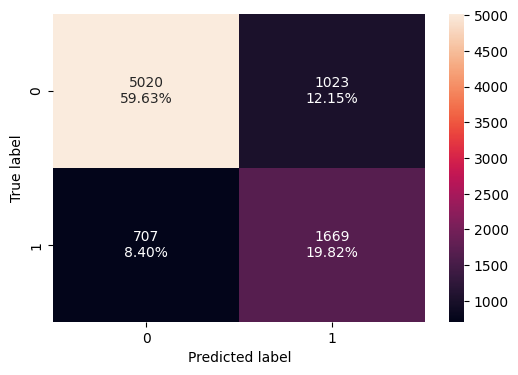

```python
# creating confusion matrix
confusion_matrix_statsmodels(lg2, X_train1, y_train, threshold=optimal_threshold_curve)
```

```python
#Checking model performance for this model
log_reg_model_train_perf_threshold_curve = model_performance_classification_statsmodels(lg2,X_train1,y_train,threshold=optimal_threshold_curve)
print('Training Performance')
log_reg_model_train_perf_threshold_curve
```

```
Training Performance
```

|  | Accuracy | Recall | Precision | F1 |
| --- | --- | --- | --- | --- |
| 0 | 0.795 | 0.702 | 0.620 | 0.659 |

# Model Performance Summary

```python
# training performance comparison

models_train_comp_df = pd.concat(
    [
        log_reg_model_train_perf.T,
        log_reg_model_train_perf_threshold_auc_roc.T,
        log_reg_model_train_perf_threshold_curve.T,
    ],
    axis=1,
)
models_train_comp_df.columns = [
    "Logistic Regression statsmodel",
    "Logistic Regression-0.34 Threshold",
    "Logistic Regression-0.40 Threshold",
]

print("Training performance comparison:")
models_train_comp_df
```

```
Training performance comparison:
```

|  | Logistic Regression statsmodel | Logistic Regression-0.34 Threshold | Logistic Regression-0.40 Threshold |
| --- | --- | --- | --- |
| Accuracy | 0.802 | 0.784 | 0.795 |
| Recall | 0.566 | 0.746 | 0.702 |
| Precision | 0.680 | 0.593 | 0.620 |
| F1 | 0.618 | 0.661 | 0.659 |

# Let's check the performance on the validation set

- **Using model with default threshold**

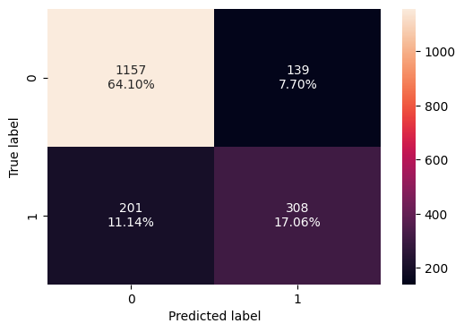

```python
# creating confusion matrix
confusion_matrix_statsmodels(lg2, X_val1, y_val)
```

```python
log_reg_model_validation_perf = model_performance_classification_statsmodels(
    lg2, X_val1, y_val
)

print("Validation performance:")
log_reg_model_validation_perf
```

```
Validation performance:
```

|  | Accuracy | Recall | Precision | F1 |
| --- | --- | --- | --- | --- |
| 0 | 0.812 | 0.605 | 0.689 | 0.644 |

**ROC-AUC curve on validation set**

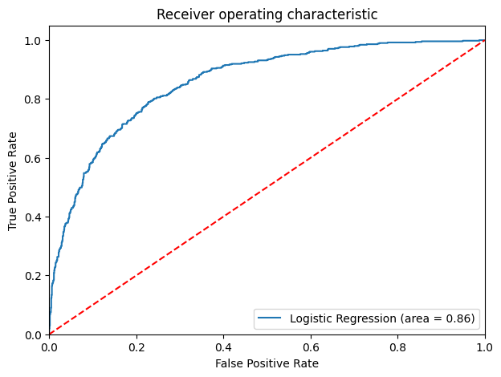

```python
logit_roc_auc_train = roc_auc_score(y_val, lg2.predict(X_val1))
fpr, tpr, thresholds = roc_curve(y_val, lg2.predict(X_val1))
plt.figure(figsize=(7, 5))
plt.plot(fpr, tpr, label="Logistic Regression (area = %0.2f)" % logit_roc_auc_train)
plt.plot([0, 1], [0, 1], "r--")
plt.xlim([0.0, 1.0])
plt.ylim([0.0, 1.05])
plt.xlabel("False Positive Rate")
plt.ylabel("True Positive Rate")
plt.title("Receiver operating characteristic")
plt.legend(loc="lower right")
plt.show()
```

# Optimal threshold using AUC-ROC curve(with 0.34 threshold)

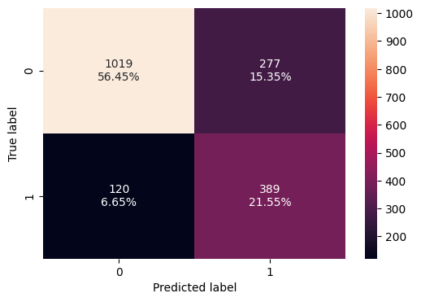

```python
# creating confusion matrix
confusion_matrix_statsmodels(lg2, X_val1, y_val, threshold=optimal_threshold_auc_roc)
```

```python
# checking model performance for this model
log_reg_model_validation_perf_threshold_auc_roc = model_performance_classification_statsmodels(
    lg2, X_val1, y_val, threshold=optimal_threshold_auc_roc
)
print("Validation performance:")
log_reg_model_validation_perf_threshold_auc_roc
```

```
Validation performance:
```

|  | Accuracy | Recall | Precision | F1 |
| --- | --- | --- | --- | --- |
| 0 | 0.780 | 0.764 | 0.584 | 0.662 |

# Checking model performance on validation set( with 0.40 threshold)

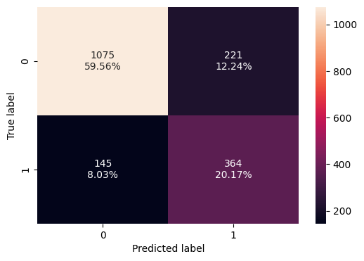

```python
# creating confusion matrix
confusion_matrix_statsmodels(lg2, X_val1, y_val, threshold=optimal_threshold_curve)
```

```python
log_reg_model_validation_perf_threshold_curve = model_performance_classification_statsmodels(
    lg2, X_val1, y_val, threshold=optimal_threshold_curve
)
print("Validation performance:")
log_reg_model_validation_perf_threshold_curve
```

```
Validation performance:
```

|  | Accuracy | Recall | Precision | F1 |
| --- | --- | --- | --- | --- |
| 0 | 0.797 | 0.715 | 0.622 | 0.665 |

# Model performance summary

```python
# validation performance comparison

models_validation_comp_df = pd.concat(
    [
        log_reg_model_validation_perf.T,
        log_reg_model_validation_perf_threshold_auc_roc.T,
        log_reg_model_validation_perf_threshold_curve.T,
    ],
    axis=1,
)
models_validation_comp_df.columns = [
    "Logistic Regression statsmodel",
    "Logistic Regression-0.34 Threshold",
    "Logistic Regression-0.40 Threshold",
]

print("Validation set performance comparison:")
models_validation_comp_df
```

```
Validation set performance comparison:
```

|  | Logistic Regression statsmodel | Logistic Regression-0.34 Threshold | Logistic Regression-0.40 Threshold |
| --- | --- | --- | --- |
| Accuracy | 0.812 | 0.780 | 0.797 |
| Recall | 0.605 | 0.764 | 0.715 |
| Precision | 0.689 | 0.584 | 0.622 |
| F1 | 0.644 | 0.662 | 0.665 |

- Based on the performance results, especially the recall values, the Logistic Regression model (with 0.34 Threshold) emerged as the most suitable choice. While it slightly reduced accuracy and precision compared to the default, it significantly increased the model's ability to correctly identify actual churners.

# Advanced Model Building

```python
# Defining a function to compute different metrics to check performance of a classification model built using sklearn
def model_performance_classification_sklearn(
    model, predictors, target, threshold=0.5
):
    """
    Function to compute different metrics to check classification model performance

    model: classifier
    predictors: independent variables
    target: dependent variable
    threshold: threshold for classifying the observation as class 1
    """

    # Get probabilities for the positive class
    y_pred_proba = model.predict_proba(predictors)[:, 1]

    # Classify based on the threshold
    y_pred = (y_pred_proba > threshold).astype(int)

    acc = accuracy_score(target, y_pred)  # to compute Accuracy
    recall = recall_score(target, y_pred)  # to compute Recall
    precision = precision_score(target, y_pred)  # to compute Precision
    f1 = f1_score(target, y_pred)  # to compute F1-score

    # creating a dataframe of metrics
    df_perf = pd.DataFrame(
        {"Accuracy": acc, "Recall": recall, "Precision": precision, "F1": f1,},
        index=[0],
    )

    return df_perf
```

# Decision Tree

```python
dtree = DecisionTreeClassifier(random_state=1)
dtree.fit(X_train, y_train)
```

```
DecisionTreeClassifier(random_state=1)
```

```python
dtree_model_train_perf=model_performance_classification_sklearn(dtree, X_train,y_train)
print("Training performance \n",dtree_model_train_perf)
```

```
Training performance
    Accuracy  Recall  Precision    F1
0     0.999   0.997      1.000 0.999
```

```python
dtree_model_validation_perf=model_performance_classification_sklearn(dtree, X_val,y_val)
print("Validation performance \n",dtree_model_validation_perf)
```

```
Validation performance
    Accuracy  Recall  Precision    F1
0     0.731   0.550      0.521 0.535
```

# Bagging

```python
bag_classifier=BaggingClassifier(random_state=1)
bag_classifier.fit(X_train,y_train)
```

```
BaggingClassifier(random_state=1)
```

```python
bag_classifier_model_train_perf=model_performance_classification_sklearn(bag_classifier, X_train,y_train)
print("Training performance \n",bag_classifier_model_train_perf)
```

```
Training performance
    Accuracy  Recall  Precision    F1
0     0.982   0.944      0.992 0.967
```

```python
bag_classifier_model_validation_perf=model_performance_classification_sklearn(bag_classifier, X_val,y_val)
print("Validation performance \n",bag_classifier_model_validation_perf)
```

```
Validation performance
    Accuracy  Recall  Precision    F1
0     0.796   0.527      0.677 0.592
```

# Random Forest

```python
rf_classifier=RandomForestClassifier(random_state=1)
rf_classifier.fit(X_train,y_train)
```

```
RandomForestClassifier(random_state=1)
```

```python
rf_classifier_model_train_perf=model_performance_classification_sklearn(rf_classifier, X_train,y_train)
print("Training performance \n",rf_classifier_model_train_perf)
```

```
Training performance
    Accuracy  Recall  Precision    F1
0     0.999   0.999      0.998 0.999
```

```python
rf_classifier_model_validation_perf=model_performance_classification_sklearn(rf_classifier, X_val,y_val)
print("Validation performance \n",rf_classifier_model_validation_perf)
```

```
Validation performance
    Accuracy  Recall  Precision    F1
0     0.803   0.566      0.681 0.618
```

# Adaboost

```python
adb_classifier=AdaBoostClassifier(random_state=1)
adb_classifier.fit(X_train,y_train)
```

```
AdaBoostClassifier(random_state=1)
```

```python
adb_classifier_model_train_perf=model_performance_classification_sklearn(adb_classifier, X_train,y_train)
print("Training performance \n",adb_classifier_model_train_perf)
```

```
Training performance
    Accuracy  Recall  Precision    F1
0     0.798   0.551      0.674 0.606
```

```python
adb_classifier_model_validation_perf=model_performance_classification_sklearn(adb_classifier, X_val,y_val)
print("Validation performance \n",adb_classifier_model_validation_perf)
```

```
Validation performance
    Accuracy  Recall  Precision    F1
0     0.811   0.576      0.701 0.632
```

# Gradient Boosting

```python
GBM_classifier=GradientBoostingClassifier(random_state=1)
GBM_classifier.fit(X_train, y_train)
```

```
GradientBoostingClassifier(random_state=1)
```

```python
GBM_classifier_model_train_perf=model_performance_classification_sklearn(GBM_classifier, X_train,y_train)
print("Training performance \n",GBM_classifier_model_train_perf)
```

```
Training performance
    Accuracy  Recall  Precision    F1
0     0.815   0.591      0.707 0.644
```

```python
GBM_classifier_model_validation_perf=model_performance_classification_sklearn(GBM_classifier, X_val,y_val)
print("Validation performance \n",GBM_classifier_model_validation_perf)
```

```
Validation performance
    Accuracy  Recall  Precision    F1
0     0.818   0.605      0.706 0.652
```

- Gradient Boosting showed a strong balance between bias and variance. It achieved high recall and F1-score on the validation set, indicating strong generalization capability. The model effectively captured complex patterns in the data and performed consistently across metrics.

# Tuning Random Forest

```python
from sklearn.ensemble import RandomForestClassifier
from sklearn.model_selection import RandomizedSearchCV
import sklearn.metrics as metrics


# Choose classifier
rf_tuned = RandomForestClassifier(
    class_weight="balanced",
    random_state=1
)

# Parameter distributions
parameters = {
    'n_estimators': [200,300,500],
    'max_depth': [6,8,10,12],
    'min_samples_leaf': [10,20,30],
    'min_samples_split': [2,5,10,15]
}

# Scorer
scorer = metrics.make_scorer(metrics.recall_score)

# RandomizedSearchCV
random_obj = RandomizedSearchCV(
    rf_tuned,
    parameters,
    scoring=scorer,
    n_iter=20,
    cv=5,
    random_state=1,
    n_jobs=-1
)

random_obj = random_obj.fit(X_train, y_train)

# Best estimator
rf_tuned = random_obj.best_estimator_

# Fit best model
rf_tuned.fit(X_train, y_train)

rf_tuned
```

```
RandomForestClassifier(class_weight='balanced', max_depth=6,
                       min_samples_leaf=30, min_samples_split=5,
                       n_estimators=500, random_state=1)
```

```python
# Evaluate the best model on the training set
rf_tuned_train_perf = model_performance_classification_sklearn(rf_tuned, X_train, y_train)
rf_tuned_train_perf
```

|  | Accuracy | Recall | Precision | F1 |
| --- | --- | --- | --- | --- |
| 0 | 0.753 | 0.810 | 0.542 | 0.649 |

```python
# Evaluate the best model on the validation set
rf_tuned_validation_perf = model_performance_classification_sklearn(rf_tuned, X_val, y_val)
rf_tuned_validation_perf
```

|  | Accuracy | Recall | Precision | F1 |
| --- | --- | --- | --- | --- |
| 0 | 0.753 | 0.817 | 0.541 | 0.651 |

- After tuning, it reduced overfitting, improved generalization, and a higher, more stable recall on unseen data, which is crucial for identifying churners.

# Tuning AdaBoost

```python
abc_tuned = AdaBoostClassifier(
    estimator=DecisionTreeClassifier(
        max_depth=2,
        class_weight="balanced"
    ),
    random_state=1
)

parameters = {
    'n_estimators': [50, 80, 100],
    'learning_rate': [0.1, 0.2, 0.3],
    'estimator__max_depth': [1, 2, 3, 4, 5, 6, 7], # Max depth of the base estimator
    'estimator__min_samples_split': [2, 5, 10],
    'estimator__min_samples_leaf': [1, 2, 4]
}


scorer = metrics.make_scorer(metrics.recall_score)

random_obj = RandomizedSearchCV(
    abc_tuned,
    parameters,
    scoring=scorer,
    cv=5,
    random_state=1,
    n_jobs=-1
)

random_obj = random_obj.fit(X_train, y_train)

abc_tuned = random_obj.best_estimator_
abc_tuned.fit(X_train, y_train)

abc_tuned
```

```
AdaBoostClassifier(estimator=DecisionTreeClassifier(class_weight='balanced',
                                                    max_depth=2,
                                                    min_samples_split=5),
                   learning_rate=0.1, random_state=1)
```

```python
# Evaluate the newly tuned AdaBoost model (RandomizedSearch) on the training set
abc_tuned_train_perf = model_performance_classification_sklearn(abc_tuned, X_train, y_train)
print("Training Performance:\n", abc_tuned_train_perf)
```

```
Training Performance:
    Accuracy  Recall  Precision    F1
0     0.706   0.858      0.488 0.622
```

```python
# Evaluate the newly tuned AdaBoost model (RandomizedSearch) on the validation set
abc_tuned_validation_perf = model_performance_classification_sklearn(abc_tuned, X_val, y_val)
print(" Validation Performance:\n", abc_tuned_validation_perf)
```

```
 Validation Performance:
    Accuracy  Recall  Precision    F1
0     0.717   0.878      0.499 0.637
```

- After tuning, the model performance improved and generalizes well on both training and validation data. Now it is more effective at identifying at-risk customers.

# Tuning Gradient Boosting

```python
from sklearn.utils.class_weight import compute_sample_weight

# Compute sample weights
gb_weights = compute_sample_weight("balanced", y_train)

# Choose classifier
gbc_tuned = GradientBoostingClassifier(random_state=1)

# Parameter distributions
parameters = {
    'n_estimators': [100,150,200,250,300],
    'learning_rate': [0.01,0.05,0.1,0.2,0.5],
    'max_depth': [3,4,5,6,7,8],
    'min_samples_leaf': [10,20,30],
    'min_samples_split':[2,5,10,15]
}

# Scorer
scorer = metrics.make_scorer(metrics.recall_score)

# RandomizedSearchCV
random_obj = RandomizedSearchCV(
    gbc_tuned,
    parameters,
    scoring=scorer,
    n_iter=20,
    cv=5,
    random_state=1,
    n_jobs=-1
)

random_obj = random_obj.fit(X_train, y_train, sample_weight=gb_weights)

# Best estimator
gbc_tuned = random_obj.best_estimator_

# Fit best model
gbc_tuned.fit(X_train, y_train, sample_weight=gb_weights)

gbc_tuned
```

```
GradientBoostingClassifier(learning_rate=0.01, max_depth=5, min_samples_leaf=20,
                           min_samples_split=15, n_estimators=250,
                           random_state=1)
```

#### **Evaluate the best tuned Gradient Boosting model on the training set**

```python
# Evaluate the best model on the training set
gbc_tuned_train_perf = model_performance_classification_sklearn(gbc_tuned, X_train, y_train)
gbc_tuned_train_perf
```

|  | Accuracy | Recall | Precision | F1 |
| --- | --- | --- | --- | --- |
| 0 | 0.781 | 0.830 | 0.578 | 0.682 |

#### **Evaluate the best tuned Gradient Boosting model on the validation set**

```python
# Evaluate the best model on the validation set
gbc_tuned_validation_perf = model_performance_classification_sklearn(gbc_tuned, X_val, y_val)
gbc_tuned_validation_perf
```

|  | Accuracy | Recall | Precision | F1 |
| --- | --- | --- | --- | --- |
| 0 | 0.768 | 0.817 | 0.561 | 0.666 |

- After tuning, the model performance improved, showing better generalization on both training and validation data. Emphasize that the tuned model is now more effective at identifying at-risk customers, especially due to improvements in recall, and discuss the overall balance achieved across various metrics.

### **Comparing all Models Performance on Training and Validation Set**

```python
# Training performance comparison for all models

all_models_train_comp_df = pd.concat(
    [
        log_reg_model_train_perf_threshold_auc_roc.T,
        dtree_model_train_perf.T,
        bag_classifier_model_train_perf.T,
        rf_classifier_model_train_perf.T,
        adb_classifier_model_train_perf.T,
        GBM_classifier_model_train_perf.T,
        rf_tuned_train_perf.T,
        abc_tuned_train_perf.T,
        gbc_tuned_train_perf.T,
    ],
    axis=1,
)
all_models_train_comp_df.columns = [
    "Logistic Regression (0.34 Threshold)",
    "Decision Tree",
    "Bagging Classifier",
    "Random Forest",
    "AdaBoost Classifier",
    "Gradient Boosting Classifier",
    "Random Forest Tuned",
    "AdaBoost Tuned",
    "Gradient Boosting Tuned",
]
print("Training performance comparison for all models:")
all_models_train_comp_df
```

```
Training performance comparison for all models:
```

|  | Logistic Regression (0.34 Threshold) | Decision Tree | Bagging Classifier | Random Forest | AdaBoost Classifier | Gradient Boosting Classifier | Random Forest Tuned | AdaBoost Tuned | Gradient Boosting Tuned |
| --- | --- | --- | --- | --- | --- | --- | --- | --- | --- |
| Accuracy | 0.784 | 0.999 | 0.982 | 0.999 | 0.798 | 0.815 | 0.753 | 0.706 | 0.781 |
| Recall | 0.746 | 0.997 | 0.944 | 0.999 | 0.551 | 0.591 | 0.810 | 0.858 | 0.830 |
| Precision | 0.593 | 1.000 | 0.992 | 0.998 | 0.674 | 0.707 | 0.542 | 0.488 | 0.578 |
| F1 | 0.661 | 0.999 | 0.967 | 0.999 | 0.606 | 0.644 | 0.649 | 0.622 | 0.682 |

```python
# Validation performance comparison for all models

all_models_validation_comp_df = pd.concat(
    [
        log_reg_model_validation_perf_threshold_auc_roc.T,
        dtree_model_validation_perf.T,
        bag_classifier_model_validation_perf.T,
        rf_classifier_model_validation_perf.T,
        adb_classifier_model_validation_perf.T,
        GBM_classifier_model_validation_perf.T,
        rf_tuned_validation_perf.T,
        abc_tuned_validation_perf.T,
        gbc_tuned_validation_perf.T,
    ],
    axis=1,
)
all_models_validation_comp_df.columns = [
    "Logistic Regression (0.34 Threshold)",
    "Decision Tree",
    "Bagging Classifier",
    "Random Forest",
    "AdaBoost Classifier",
    "Gradient Boosting Classifier",
    "Random Forest Tuned",
    "AdaBoost Tuned",
    "Gradient Boosting Tuned",
]
print("Validation performance comparison for all models:")
all_models_validation_comp_df
```

```
Validation performance comparison for all models:
```

|  | Logistic Regression (0.34 Threshold) | Decision Tree | Bagging Classifier | Random Forest | AdaBoost Classifier | Gradient Boosting Classifier | Random Forest Tuned | AdaBoost Tuned | Gradient Boosting Tuned |
| --- | --- | --- | --- | --- | --- | --- | --- | --- | --- |
| Accuracy | 0.780 | 0.731 | 0.796 | 0.803 | 0.811 | 0.818 | 0.753 | 0.717 | 0.768 |
| Recall | 0.764 | 0.550 | 0.527 | 0.566 | 0.576 | 0.605 | 0.817 | 0.878 | 0.817 |
| Precision | 0.584 | 0.521 | 0.677 | 0.681 | 0.701 | 0.706 | 0.541 | 0.499 | 0.561 |
| F1 | 0.662 | 0.535 | 0.592 | 0.618 | 0.632 | 0.652 | 0.651 | 0.637 | 0.666 |

**Now we have our final model, so let's find out how our final model is performing on unseen test data.**

```python
# Let's check the performance on test set
gbc_tuned_test_perf= model_performance_classification_sklearn(gbc_tuned, X_test, y_test)
gbc_tuned_test_perf
```

|  | Accuracy | Recall | Precision | F1 |
| --- | --- | --- | --- | --- |
| 0 | 0.773 | 0.790 | 0.571 | 0.663 |

- the Tuned Gradient Boosting model is a suitable choice for our needs and effectively applicable for Customer Churn prediction.

# Feature Importances

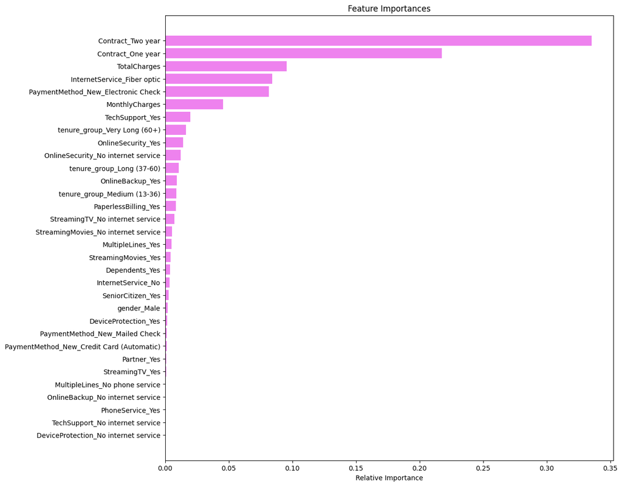

```python
feature_names = X_train.columns
importances =  gbc_tuned.feature_importances_
indices = np.argsort(importances)

plt.figure(figsize=(12, 12))
plt.title("Feature Importances")
plt.barh(range(len(indices)), importances[indices], color="violet", align="center")
plt.yticks(range(len(indices)), [feature_names[i] for i in indices])
plt.xlabel("Relative Importance")
plt.show()
```

# **Actionable Insights and Recommandations**

> **Insights:**

The analysis identifies several critical factors that drive customer churn at AlphaCom:

- **Contract Type Influence**: Contract type is a primary indicator of churn risk. Customers on month-to-month contracts exhibit significantly higher churn rates compared to those on one-year or two-year contracts.
- **Service Bundle Impact:** Lack of specialized services like Online Security, Tech Support, and Online Backup is strongly correlated with increased churn. Conversely, customers who subscribe to these services are more likely to stay.
- **Internet Service Quality:** Customers using Fiber Optic internet services show a higher propensity for churn than those using DSL. This often suggests potential issues with service quality, pricing, or perceived value for fiber customers.
- **Tenure and Loyalty:** Customer tenure is a significant predictor; the risk of churn is highest during the initial months of service. As tenure increases, customers generally become more loyal.
- **Financial Factors:** High Monthly Charges are a major driver of churn, particularly if customers do not perceive high value for the price.
- **Payment Methods:** Customers using Electronic Checks as their payment method tend to churn at a higher rate than those using automated payment methods like bank transfers or credit cards.

> **Actionable Business Recommendations:**

To mitigate churn and improve retention, AlphaCom should implement the following strategies:

- **Incentivize Long-Term Contracts:**

Offer discounts or loyalty rewards to encourage month-to-month customers to migrate to one-year or two-year contracts.

Introduce "early-bird" renewal benefits for customers approaching the end of their long-term contracts.

- **Promote Security and Support Bundles:**

Create service bundles that include Online Security and Tech Support at a discounted rate for new customers.

Target high-risk fiber optic customers with free trials of premium tech support or device protection to increase the "stickiness" of their plans.

- **Targeted Outreach for Fiber Optic Users:**

Conduct targeted surveys specifically for Fiber Optic customers to identify pain points regarding service stability or pricing.

Implement a "proactive outreach" program where technical teams verify line quality for fiber users in high-churn areas.

- **Focus on Early-Stage Retention:**

Implement an onboarding program for the first 3–6 months that includes regular check-ins and tailored tutorials on how to maximize their service value.

Offer a "loyalty bonus" (e.g., a one-time bill credit) after the first 6 months of continuous service.

- **Optimize Payment and Billing:**

Encourage the adoption of Automated Payment Methods (Credit Card/Bank Transfer) by offering a small monthly discount (e.g., $2–$5 off).

Streamline the paperless billing interface to ensure customers can easily understand their monthly charges, reducing frustration that leads to churn.

> **Conclusion**

```python
#!jupyter nbconvert --to html Sandipan_Roy_Capstone_Project_Notebook.ipynb
```